# PrestoGP practice example with package data

```r
.libPaths("/usr/local/lib/R/site-library")
library(PrestoGP)
library(ggplot2)
set.seed(2025)
```

## Load data and prepare

Pull the example dataset, drop rows with a missing covariate, and define the outcome (y), predictors (X), and spatial coordinates (locs). Print basic dimensions to sanity-check.

```r
data(soil, package = "PrestoGP")
soil <- soil[!is.na(soil[,5]),]
y <- soil[,4]             # moisture content
X <- as.matrix(soil[,5:9])
locs <- as.matrix(soil[,1:2])
str(list(y=y, X=dim(X), locs=dim(locs)))
```

```
## List of 3
##  $ y   : num [1:200] 7.23 14.63 12.67 13.73 7.4 ...
##  $ X   : int [1:2] 200 5
##  $ locs: int [1:2] 200 2
```

## Fit models

Fit a sparse Gaussian process (Vecchia approximation with 10 neighbors) to model moisture as a function of covariates and spatial correlation. Show estimated Matérn parameters and regression coefficients.

```r
soil.vm <- new("VecchiaModel", n_neighbors = 10)
soil.vm <- prestogp_fit(soil.vm, y, X, locs)
```

```
##
## Estimating initial beta...
## Estimation of initial beta complete
##
## Beginning iteration 1
## Estimating theta...
## Estimation of theta complete
## Estimating beta...
## Estimation of beta complete
## Iteration 1 complete
## Current penalized negative log likelihood: 487.701
## Current MSE: 9.104869
## Beginning iteration 2
## Estimating theta...
## Estimation of theta complete
## Estimating beta...
## Estimation of beta complete
## Iteration 2 complete
## Current penalized negative log likelihood: 482.5181
## Current MSE: 9.040968
## Beginning iteration 3
## Estimating theta...
## Estimation of theta complete
## Estimating beta...
## Estimation of beta complete
## Iteration 3 complete
## Current penalized negative log likelihood: 482.1626
## Current MSE: 9.040136
## Beginning iteration 4
## Estimating theta...
## Estimation of theta complete
## Estimating beta...
## Estimation of beta complete
## Iteration 4 complete
## Current penalized negative log likelihood: 482.1467
## Current MSE: 9.04814
## Beginning iteration 5
## Estimating theta...
## Estimation of theta complete
## Estimating beta...
## Estimation of beta complete
## Iteration 5 complete
## Current penalized negative log likelihood: 482.1467
## Current MSE: 9.018459
```

```r
soil.vm
```

```
## Matern covariance parameters (theta):
## $sigma
## [1] 10.28376
##
## $scale
## [1] 13.52572
##
## $smoothness
## [1] 0.9088149
##
## $nuggets
## [1] 0.7629514
##
## Regression coefficients (beta):
## $Y
##        NO3.N        NH4.N          DOC         N20N
## -0.030153253  0.023570590  0.001740194 14.502823295
##
## $`(Intercept)`
## (Intercept)
##    11.40227
##
## Model type: VecchiaModel
## Nearest neighbors: 10
## Scaling: 1 1
## Penalized likelihood: 482.1467
## MSE: 9.018459
```

## Impute missing y values

Randomly create 20 missing outcomes and refit with joint imputation (impute.y=TRUE). The model iterates: estimate covariance/mean, then impute missing y, and repeats until stable. Print results.

```r
miss <- sample(1:nrow(soil), 20)
y.miss <- y
y.miss[miss] <- NA
soil.vm2 <- new("VecchiaModel", n_neighbors = 10)
soil.vm2 <- prestogp_fit(soil.vm2, y.miss, X, locs, impute.y = TRUE)
```

```
##
## Estimating initial beta...
## Estimation of initial beta complete
##
## Beginning iteration 1
## Estimating theta...
## Estimation of theta complete
## Estimating beta...
## Estimation of beta complete
## Imputing missing y's...
## Imputation complete
## Iteration 1 complete
## Current penalized negative log likelihood: 478.5195
## Current MSE: 7.992472
## Beginning iteration 2
## Estimating theta...
## Estimation of theta complete
## Estimating beta...
## Estimation of beta complete
## Imputing missing y's...
## Imputation complete
## Iteration 2 complete
## Current penalized negative log likelihood: 470.7962
## Current MSE: 8.095935
## Beginning iteration 3
## Estimating theta...
## Estimation of theta complete
## Estimating beta...
## Estimation of beta complete
## Imputing missing y's...
## Imputation complete
## Iteration 3 complete
## Current penalized negative log likelihood: 469.8038
## Current MSE: 8.124704
## Beginning iteration 4
## Estimating theta...
## Estimation of theta complete
## Estimating beta...
## Estimation of beta complete
## Imputing missing y's...
```

[output cut: 27 more lines]

```
## Estimating beta...
## Estimation of beta complete
## Imputing missing y's...
## Imputation complete
## Iteration 7 complete
## Current penalized negative log likelihood: 468.1649
## Current MSE: 8.165805
## Beginning iteration 8
## Estimating theta...
## Estimation of theta complete
## Estimating beta...
## Estimation of beta complete
## Iteration 8 complete
## Current penalized negative log likelihood: 468.1649
## Current MSE: 8.161238
```

```r
soil.vm2
```

```
## Matern covariance parameters (theta):
## $sigma
## [1] 9.561545
##
## $scale
## [1] 12.23572
##
## $smoothness
## [1] 1.038871
##
## $nuggets
## [1] 0.770053
##
## Regression coefficients (beta):
## $Y
##       NO3.N       NH4.N         DOC
## -0.04352194  0.02984236  0.00360866
##
## $`(Intercept)`
## (Intercept)
##    11.31979
##
## Model type: VecchiaModel
## Nearest neighbors: 10
## Scaling: 1 1
## Penalized likelihood: 468.1649
## MSE: 8.161238
```

## Impute y values missing due to limit of detection

Treat low values as left-censored at the 10th percentile (proxy LOD). Refit with censored-value imputation by providing lod.upper. Print the fitted parameters for comparison.

```r
soil.lod <- quantile(y, 0.1)
y.lod <- y
y.lod[y.lod <= soil.lod] <- NA
soil.vm3 <- new("VecchiaModel", n_neighbors = 10)
soil.vm3 <- prestogp_fit(soil.vm3, y.lod, X, locs, impute.y = TRUE, lod.upper = soil.lod)
```

```
##
## Imputing missing y's and estimating initial beta...
## Estimation of initial beta complete
##
## Beginning iteration 1
## Estimating theta...
## Estimation of theta complete
## Imputing missing y's...
## Imputation complete
## Estimating beta...
## Estimation of beta complete
## Iteration 1 complete
## Current penalized negative log likelihood: 490.7925
## Current MSE: 9.468412
## Beginning iteration 2
## Estimating theta...
## Estimation of theta complete
## Imputing missing y's...
## Imputation complete
## Estimating beta...
## Estimation of beta complete
## Iteration 2 complete
## Current penalized negative log likelihood: 474.7767
## Current MSE: 8.544219
## Beginning iteration 3
## Estimating theta...
## Estimation of theta complete
## Imputing missing y's...
## Imputation complete
## Estimating beta...
## Estimation of beta complete
## Iteration 3 complete
## Current penalized negative log likelihood: 474.6977
## Current MSE: 8.540108
## Beginning iteration 4
## Estimating theta...
## Estimation of theta complete
## Imputing missing y's...
## Imputation complete
## Estimating beta...
## Estimation of beta complete
## Iteration 4 complete
## Current penalized negative log likelihood: 474.6977
## Current MSE: 8.537138
```

```r
soil.vm3
```

```
## Matern covariance parameters (theta):
## $sigma
## [1] 9.732538
##
## $scale
## [1] 20.23945
##
## $smoothness
## [1] 0.6619094
##
## $nuggets
## [1] 0.833824
##
## Regression coefficients (beta):
## $Y
##        NO3.N        NH4.N          DOC         N20N
## -0.029170373  0.023776871  0.002438894 38.499060962
##
## $`(Intercept)`
## (Intercept)
##    11.47614
##
## Model type: VecchiaModel
## Nearest neighbors: 10
## Scaling: 1 1
## Penalized likelihood: 474.6977
## MSE: 8.537138
```

## Fit full model

Fit the exact (dense) Gaussian process to the same data for a baseline comparison against the Vecchia approximation. Display parameters and fit metrics.

```r
soil.fm <- new("FullModel")
soil.fm <- prestogp_fit(soil.fm, y, X, locs)
```

```
##
## Estimating initial beta...
## Estimation of initial beta complete
##
## Beginning iteration 1
## Estimating theta...
## Estimation of theta complete
## Estimating beta...
## Estimation of beta complete
## Iteration 1 complete
## Current penalized negative log likelihood: 487.4753
## Current MSE: 9.104869
## Beginning iteration 2
## Estimating theta...
## Estimation of theta complete
## Estimating beta...
## Estimation of beta complete
## Iteration 2 complete
## Current penalized negative log likelihood: 482.3228
## Current MSE: 9.070959
## Beginning iteration 3
## Estimating theta...
## Estimation of theta complete
## Estimating beta...
## Estimation of beta complete
## Iteration 3 complete
## Current penalized negative log likelihood: 482.3228
## Current MSE: 9.059007
```

```r
soil.fm
```

```
## Matern covariance parameters (theta):
## $sigma
## [1] 9.982897
##
## $scale
## [1] 16.75031
##
## $smoothness
## [1] 0.7428679
##
## $nuggets
## [1] 1.008947
##
## Regression coefficients (beta):
## $Y
##       NO3.N       NH4.N         DOC        N20N
## -0.03129842  0.02401686  0.00287257  1.65486907
##
## $`(Intercept)`
## (Intercept)
##    11.35368
##
## Model type: FullModel
## Scaling: 1 1
## Penalized likelihood: 482.3228
## MSE: 9.059007
```

## Fit multivariate model

Fit a multivariate Vecchia GP to two nitrogen outcomes with shared locations and covariates. The model estimates separate Matérn terms per outcome plus cross-correlation, and regression coefficients per outcome. Print results.

```r
ym <- list(soil[,5], soil[,7])                 # two nitrogen concentrations
Xm <- list(); Xm[[1]] <- Xm[[2]] <- as.matrix(soil[,c(4,6,8,9)])
locsm <- list(); locsm[[1]] <- locsm[[2]] <- locs

soil.mvm <- new("MultivariateVecchiaModel", n_neighbors = 10)
soil.mvm <- prestogp_fit(soil.mvm, ym, Xm, locsm)
```

```
##
## Estimating initial beta...
## Estimation of initial beta complete
##
## Beginning iteration 1
## Estimating theta...
## Estimation of theta complete
## Estimating beta...
## Estimation of beta complete
## Iteration 1 complete
## Current penalized negative log likelihood: 1295.582
## Current MSE: 45.73893
## Beginning iteration 2
## Estimating theta...
## Estimation of theta complete
## Estimating beta...
## Estimation of beta complete
## Iteration 2 complete
## Current penalized negative log likelihood: 1292.397
## Current MSE: 180.5448
## Beginning iteration 3
## Estimating theta...
## Estimation of theta complete
## Estimating beta...
## Estimation of beta complete
## Iteration 3 complete
## Current penalized negative log likelihood: 1292.397
## Current MSE: 182.967
```

```r
soil.mvm
```

```
## Matern covariance parameters (theta):
## $sigma
##        Y1        Y2
## 186.47453  98.15909
##
## $scale
##       Y1       Y2
## 1539.916  857.137
##
## $smoothness
##        Y1        Y2
## 0.1633968 0.1446499
##
## $nuggets
##        Y1        Y2
## 13.604061  8.073504
##
## $correlation
##            Y1         Y2
## Y1  1.0000000 -0.9999945
## Y2 -0.9999945  1.0000000
##
## Regression coefficients (beta):
## $Y1
##      moisture       Total.N           DOC          N20N
## -4.849849e-01  3.710359e-01 -1.965235e-02 -2.029138e+03
##
## $Y2
##    moisture     Total.N         DOC        N20N
##  0.37671320  0.51919107 -0.05293256 83.40904911
##
## $`(Intercept)`
## (Intercept)          Y2
##    18.81099   -45.82523
##
## Model type: MultivariateVecchiaModel
## Nearest neighbors: 10
## Scaling: 1 1
## Penalized likelihood: 1292.397
## MSE: 182.967
```

## Fit spatial-elevation model

Use another dataset with elevation as a third coordinate. Fit a Vecchia GP with coordinate scaling (c(1,1,2)) to allow different correlation ranges horizontally vs along elevation. Show fitted parameters.

```r
library(geoR)
data(soil250, package = "geoR")
y2 <- soil250[,7]                            # pH
X2 <- as.matrix(soil250[,c(4:6,8:22)])
locs2 <- as.matrix(soil250[,1:3])            # x, y, elevation

soil.vm.elev <- new("VecchiaModel", n_neighbors = 10)
soil.vm.elev <- prestogp_fit(soil.vm.elev, y2, X2, locs2, scaling = c(1,1,2))
```

```
##
## Estimating initial beta...
## Estimation of initial beta complete
##
## Beginning iteration 1
## Estimating theta...
## Estimation of theta complete
## Estimating beta...
## Estimation of beta complete
## Iteration 1 complete
## Current penalized negative log likelihood: -259.0478
## Current MSE: 0.008204926
## Beginning iteration 2
## Estimating theta...
## Estimation of theta complete
## Estimating beta...
## Estimation of beta complete
## Iteration 2 complete
## Current penalized negative log likelihood: -259.0478
## Current MSE: 0.008569788
```

```r
soil.vm.elev
```

```
## Matern covariance parameters (theta):
## $sigma
## [1] 0.004937906
##
## $scale
##       <NA>       <NA>
## 3.45006718 0.03029409
##
## $smoothness
## [1] 1.463192
##
## $nuggets
## [1] 0.003340201
##
## Regression coefficients (beta):
## $Y
##       AGrossa         Silte        Argila         pHKCl            Mg
## -0.0327999969 -0.0178079433 -0.0112530406  0.4770506171  0.1721217709
##             K            Al             C             N             S
##  0.1476813620  1.6331061949 -0.1381898726 -0.5666089782  0.0470398149
##             V             M            NC           CEC            CN
## -0.0265493087 -0.0926270549 -0.2026853615  0.1230795779 -0.0005229466
##
## $`(Intercept)`
## (Intercept)
##    5.755836
##
## Model type: VecchiaModel
## Nearest neighbors: 10
## Scaling: 1 1 2
## Penalized likelihood: -259.0478
## MSE: 0.008569788
```

## Plot moisture vs first covariate

Quick exploratory scatter plot of moisture vs the first predictor to visualize their relationship.

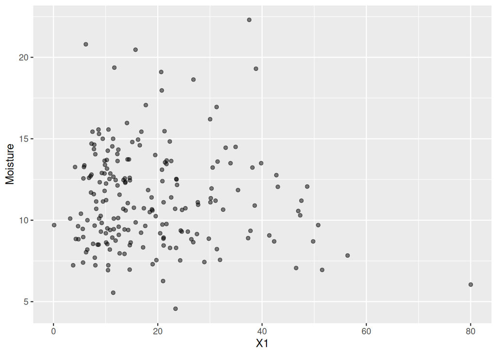

```r
df_plot <- data.frame(y = y, x = X[,1])
ggplot(df_plot, aes(x, y)) + geom_point(alpha = 0.5) + labs(x="X1", y="Moisture")
```